# 5 Dimension reduction

## Task 1: Show a graphical overview of the data

**Show a graphical overview of the data and show summaries of the variables in the data. Describe and interpret the outputs, commenting on the distributions of the variables and the relationships between them.**

```r
library(tidyverse); library(psych); library(kableExtra); library(GGally); library(corrplot)
data <- read.table("data/human.csv", sep = ",", header = T, row.names = 1)
```

Original data from is from [United Nations’ Human Development Reports](http://hdr.undp.org/en/content/human-development-index-hdi). The data combines several indicators from most countries in the world. Our modified analysis dataset has following variables:

**Table 1** Variables in the dataset

| Variables | Information |
| --- | --- |
| edu2FM | Proportion of females with at least secondary education devided by proportion of men with at least secondary education |
| labFM | Proportion of femals in the larbour force devided by proportion of males in the labour force |
| edu.exp | Expected years of schooling |
| life.exp | Life expectancy at birth |
| gni | Gross National Income per capita |
| mat.mor | Maternal mortality ratio |
| ado.birth | Adolescent birth rate |
| parlF | Proportion of female representatives in parliament |

(Script for data modification can be found [here](https://github.com/jarvinenjussi/IODS-project/blob/master/data/create_human.R).)

```r
glimpse(data)
```

```
## Observations: 155
## Variables: 8
## $ edu2FM    <dbl> 1.0072389, 0.9968288, 0.9834369, 0.9886128, 0.969060...
## $ labFM     <dbl> 0.8908297, 0.8189415, 0.8251001, 0.8840361, 0.828611...
## $ edu.exp   <dbl> 17.5, 20.2, 15.8, 18.7, 17.9, 16.5, 18.6, 16.5, 15.9...
## $ life.exp  <dbl> 81.6, 82.4, 83.0, 80.2, 81.6, 80.9, 80.9, 79.1, 82.0...
## $ gni       <int> 64992, 42261, 56431, 44025, 45435, 43919, 39568, 529...
## $ mat.mor   <int> 4, 6, 6, 5, 6, 7, 9, 28, 11, 8, 6, 4, 8, 4, 27, 2, 1...
## $ ado.birth <dbl> 7.8, 12.1, 1.9, 5.1, 6.2, 3.8, 8.2, 31.0, 14.5, 25.3...
## $ parlF     <dbl> 39.6, 30.5, 28.5, 38.0, 36.9, 36.9, 19.9, 19.4, 28.2...
```

```r
summary(data)
```

```
##      edu2FM           labFM           edu.exp         life.exp
##  Min.   :0.1717   Min.   :0.1857   Min.   : 5.40   Min.   :49.00
##  1st Qu.:0.7264   1st Qu.:0.5984   1st Qu.:11.25   1st Qu.:66.30
##  Median :0.9375   Median :0.7535   Median :13.50   Median :74.20
##  Mean   :0.8529   Mean   :0.7074   Mean   :13.18   Mean   :71.65
##  3rd Qu.:0.9968   3rd Qu.:0.8535   3rd Qu.:15.20   3rd Qu.:77.25
##  Max.   :1.4967   Max.   :1.0380   Max.   :20.20   Max.   :83.50
##       gni            mat.mor         ado.birth          parlF
##  Min.   :   581   Min.   :   1.0   Min.   :  0.60   Min.   : 0.00
##  1st Qu.:  4198   1st Qu.:  11.5   1st Qu.: 12.65   1st Qu.:12.40
##  Median : 12040   Median :  49.0   Median : 33.60   Median :19.30
##  Mean   : 17628   Mean   : 149.1   Mean   : 47.16   Mean   :20.91
##  3rd Qu.: 24512   3rd Qu.: 190.0   3rd Qu.: 71.95   3rd Qu.:27.95
##  Max.   :123124   Max.   :1100.0   Max.   :204.80   Max.   :57.50
```

```r
describe(data) %>% kable(digits = 2, caption = "<b>Table 2</b> Descriptives") %>%
  kable_styling(bootstrap_options = c("hover", "striped"))
```

**Table 2** Descriptives

|  | vars | n | mean | sd | median | trimmed | mad | min | max | range | skew | kurtosis | se |
| --- | --- | --- | --- | --- | --- | --- | --- | --- | --- | --- | --- | --- | --- |
| edu2FM | 1 | 155 | 0.85 | 0.24 | 0.94 | 0.87 | 0.12 | 0.17 | 1.50 | 1.33 | -0.76 | 0.55 | 0.02 |
| labFM | 2 | 155 | 0.71 | 0.20 | 0.75 | 0.73 | 0.17 | 0.19 | 1.04 | 0.85 | -0.87 | 0.05 | 0.02 |
| edu.exp | 3 | 155 | 13.18 | 2.84 | 13.50 | 13.24 | 2.97 | 5.40 | 20.20 | 14.80 | -0.20 | -0.34 | 0.23 |
| life.exp | 4 | 155 | 71.65 | 8.33 | 74.20 | 72.40 | 7.56 | 49.00 | 83.50 | 34.50 | -0.76 | -0.15 | 0.67 |
| gni | 5 | 155 | 17627.90 | 18543.85 | 12040.00 | 14552.58 | 13337.47 | 581.00 | 123124.00 | 122543.00 | 2.14 | 6.83 | 1489.48 |
| mat.mor | 6 | 155 | 149.08 | 211.79 | 49.00 | 104.70 | 63.75 | 1.00 | 1100.00 | 1099.00 | 2.03 | 4.16 | 17.01 |
| ado.birth | 7 | 155 | 47.16 | 41.11 | 33.60 | 41.62 | 35.73 | 0.60 | 204.80 | 204.20 | 1.13 | 0.89 | 3.30 |
| parlF | 8 | 155 | 20.91 | 11.49 | 19.30 | 20.32 | 11.42 | 0.00 | 57.50 | 57.50 | 0.55 | -0.10 | 0.92 |

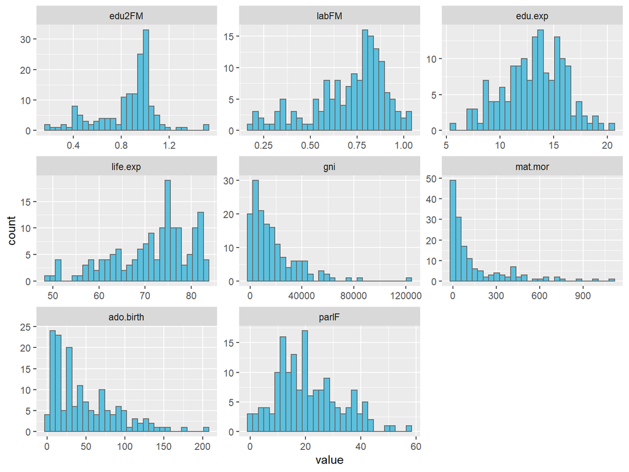

```r
# histograms
data %>%
  gather(factor_key = T) %>%
  ggplot(aes(value)) +
  facet_wrap(~ key, scales = "free") +
  geom_histogram(color="grey40", fill="#5bc0de", bins = 30)
```

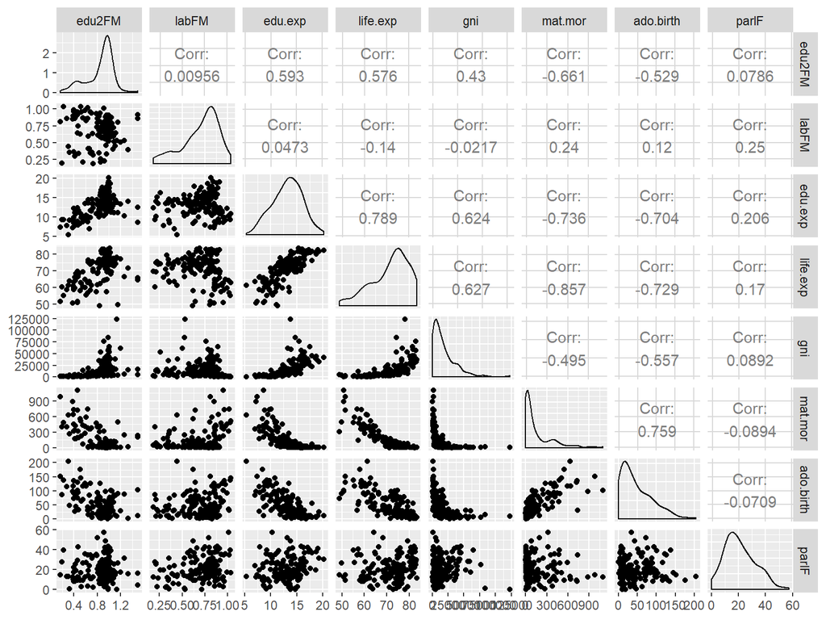

```r
# pairs
data %>% ggpairs()
```

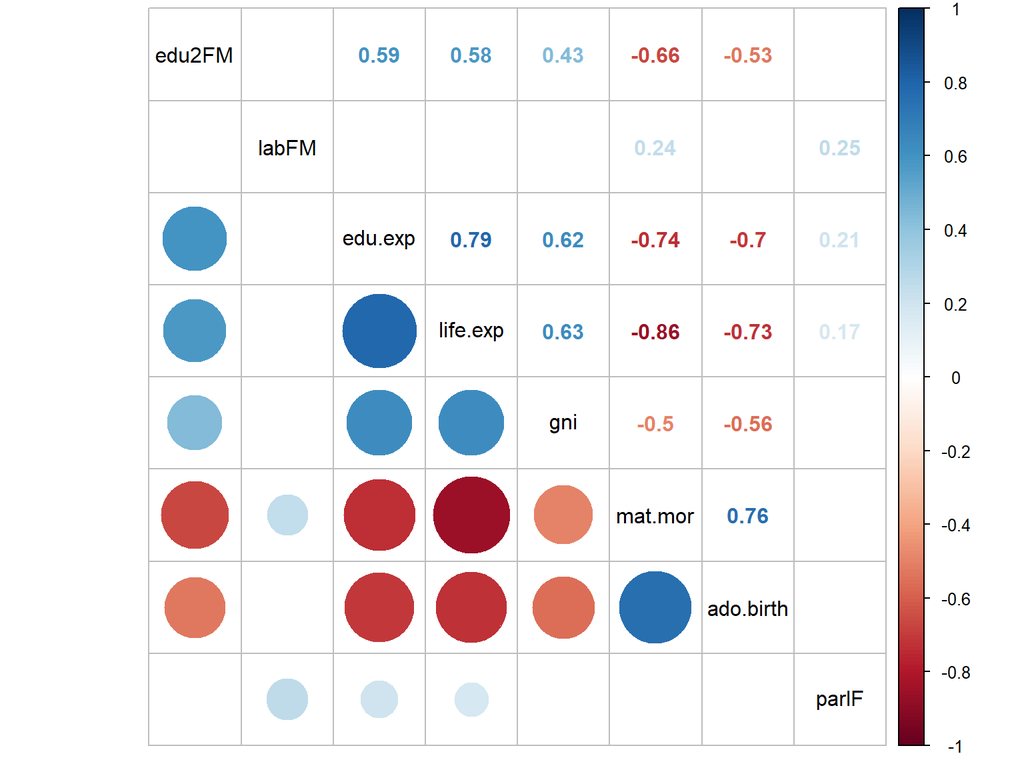

```r
# correlogram
cor.mat <- cor(data, use = "everything")

cor.mtest <- function(cor.mat, ...) {
    mat <- as.matrix(cor.mat)
    n <- ncol(cor.mat)
    p.mat<- matrix(NA, n, n)
    diag(p.mat) <- 0
    for (i in 1:(n - 1)) {
        for (j in (i + 1):n) {
            tmp <- cor.test(mat[, i], mat[, j], ...)
            p.mat[i, j] <- p.mat[j, i] <- tmp$p.value
        }
    }
  colnames(p.mat) <- rownames(p.mat) <- colnames(mat)
  p.mat
}
p.mat <- cor.mtest(data)
corrplot.mixed(cor.mat, lower = "circle", upper = "number", tl.col = "black",
               tl.cex = 1, number.cex = 1, number.digits = 2,
               p.mat = p.mat, sig.level = 0.05, insig = "blank")
```

## Tasks 2: Principal component analysis

**Perform principal component analysis (PCA) on the not standardized human data. Show the variability captured by the principal components. Draw a biplot displaying the observations by the first two principal components (PC1 coordinate in x-axis, PC2 coordinate in y-axis), along with arrows representing the original variables.**

```r
# pca1
pca1 <- prcomp(data)
s1 <- summary(pca1)
s1
```

```
## Importance of components:
##                              PC1      PC2   PC3   PC4   PC5   PC6    PC7
## Standard deviation     1.854e+04 185.5219 25.19 11.45 3.766 1.566 0.1912
## Proportion of Variance 9.999e-01   0.0001  0.00  0.00 0.000 0.000 0.0000
## Cumulative Proportion  9.999e-01   1.0000  1.00  1.00 1.000 1.000 1.0000
##                           PC8
## Standard deviation     0.1591
## Proportion of Variance 0.0000
## Cumulative Proportion  1.0000
```

```r
pca_pr1 <- round(100*s1$importance[2, ], digits = 2)
pca_pr1
```

```
##   PC1   PC2   PC3   PC4   PC5   PC6   PC7   PC8
## 99.99  0.01  0.00  0.00  0.00  0.00  0.00  0.00
```

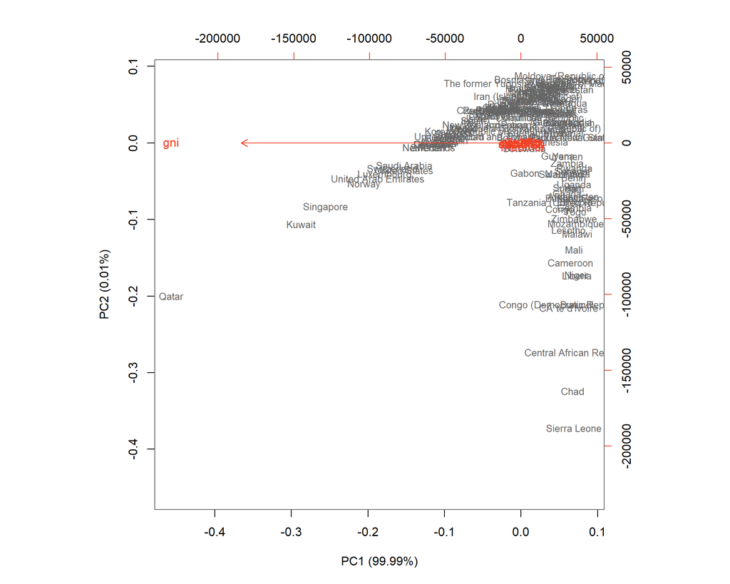

```r
pca1_lab <- paste0(names(pca_pr1), " (", pca_pr1, "%)")

biplot(pca1, cex = c(0.8, 1), col = c("grey40", "#f04124"),
       xlab = pca1_lab[1], ylab = pca1_lab[2])
```

## Task 3: PCA with standardized variables

**Standardize the variables in the human data and repeat the above analysis. Interpret the results of both analysis (with and without standardizing). Are the results different? Why or why not? Include captions (brief descriptions) in your plots where you describe the results by using not just your variable names, but the actual phenomenons they relate to.**

```r
# standardizing data
data_std <- scale(data)
summary(data_std)
```

```
##      edu2FM            labFM            edu.exp           life.exp
##  Min.   :-2.8189   Min.   :-2.6247   Min.   :-2.7378   Min.   :-2.7188
##  1st Qu.:-0.5233   1st Qu.:-0.5484   1st Qu.:-0.6782   1st Qu.:-0.6425
##  Median : 0.3503   Median : 0.2316   Median : 0.1140   Median : 0.3056
##  Mean   : 0.0000   Mean   : 0.0000   Mean   : 0.0000   Mean   : 0.0000
##  3rd Qu.: 0.5958   3rd Qu.: 0.7350   3rd Qu.: 0.7126   3rd Qu.: 0.6717
##  Max.   : 2.6646   Max.   : 1.6632   Max.   : 2.4730   Max.   : 1.4218
##       gni             mat.mor          ado.birth           parlF
##  Min.   :-0.9193   Min.   :-0.6992   Min.   :-1.1325   Min.   :-1.8203
##  1st Qu.:-0.7243   1st Qu.:-0.6496   1st Qu.:-0.8394   1st Qu.:-0.7409
##  Median :-0.3013   Median :-0.4726   Median :-0.3298   Median :-0.1403
##  Mean   : 0.0000   Mean   : 0.0000   Mean   : 0.0000   Mean   : 0.0000
##  3rd Qu.: 0.3712   3rd Qu.: 0.1932   3rd Qu.: 0.6030   3rd Qu.: 0.6127
##  Max.   : 5.6890   Max.   : 4.4899   Max.   : 3.8344   Max.   : 3.1850
```

```r
# pca2
pca2 <- prcomp(data_std)
s2 <- summary(pca2)
s2
```

```
## Importance of components:
##                           PC1    PC2     PC3     PC4     PC5     PC6
## Standard deviation     2.0708 1.1397 0.87505 0.77886 0.66196 0.53631
## Proportion of Variance 0.5361 0.1624 0.09571 0.07583 0.05477 0.03595
## Cumulative Proportion  0.5361 0.6984 0.79413 0.86996 0.92473 0.96069
##                            PC7     PC8
## Standard deviation     0.45900 0.32224
## Proportion of Variance 0.02634 0.01298
## Cumulative Proportion  0.98702 1.00000
```

```r
pca_pr2 <- round(100*s2$importance[2, ], digits = 2)
pca_pr2
```

```
##   PC1   PC2   PC3   PC4   PC5   PC6   PC7   PC8
## 53.61 16.24  9.57  7.58  5.48  3.60  2.63  1.30
```

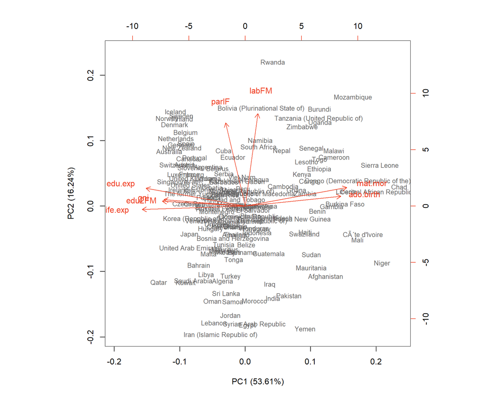

```r
pca2_lab <- paste0(names(pca_pr2), " (", pca_pr2, "%)")

biplot(pca2, cex = c(0.8, 1), col = c("grey40", "#f04124"),
       xlab = pca2_lab[1], ylab = pca2_lab[2])
```

GNI dominates the components in PCA with un-standardized variables and the first principal component accounts for almost 100 % of the total variance of the observed vairables, whereas the results of PCA with standardized variables are make more sense. The differences are due to the standardization. More specifically, when principal components are extracted from the covariance matrix (un-standardzed), the results depend on the units of measurement, and large differences between the variances of the orginal variances affect the solution. Extracting the principal components from the correlation matrix (standardized to have unit of variance) makes the variables “equally important”.

The biplot of standardized PCA show that parlF and labFM load mostly to the second component PC2, which accounts for 16 % of the total variance in the variables, while other variables load to the first component PC1, which accounts for 54 % of the variance.

## Task 4: Interpreting the results

**Give your personal interpretations of the first two principal component dimensions based on the biplot drawn after PCA on the standardized human data.**

The first component seems to be the measure of general well-being indicators, such as GNI, life expectancy, education, mortality, and birth rate, whereas the second component seems to capture the variance in gender equality indicators, namely proportion of female representatives in parliament and the Female-Male ratio in labor force.

## Task 5: Multiple Correspondence Analysis

**Load the tea dataset from the package Factominer. Explore the data briefly: look at the structure and the dimensions of the data and visualize it. Then do Multiple Correspondence Analysis on the tea data (or to a certain columns of the data, it’s up to you). Interpret the results of the MCA and draw at least the variable biplot of the analysis. You can also explore other plotting options for MCA. Comment on the output of the plots.**

### The Tea dataset

300 tea consumers have answered a survey about how they drink tea, what are their product’s perception and some personal details. Except for the age, all the variables are categorical. For the age, the data set has two different variables: a continuous and a categorical one.

```r
library(FactoMineR)
data(tea)
glimpse(tea)
```

```
## Observations: 300
## Variables: 36
## $ breakfast        <fct> breakfast, breakfast, Not.breakfast, Not.brea...
## $ tea.time         <fct> Not.tea time, Not.tea time, tea time, Not.tea...
## $ evening          <fct> Not.evening, Not.evening, evening, Not.evenin...
## $ lunch            <fct> Not.lunch, Not.lunch, Not.lunch, Not.lunch, N...
## $ dinner           <fct> Not.dinner, Not.dinner, dinner, dinner, Not.d...
## $ always           <fct> Not.always, Not.always, Not.always, Not.alway...
## $ home             <fct> home, home, home, home, home, home, home, hom...
## $ work             <fct> Not.work, Not.work, work, Not.work, Not.work,...
## $ tearoom          <fct> Not.tearoom, Not.tearoom, Not.tearoom, Not.te...
## $ friends          <fct> Not.friends, Not.friends, friends, Not.friend...
## $ resto            <fct> Not.resto, Not.resto, resto, Not.resto, Not.r...
## $ pub              <fct> Not.pub, Not.pub, Not.pub, Not.pub, Not.pub, ...
## $ Tea              <fct> black, black, Earl Grey, Earl Grey, Earl Grey...
```

[output cut: 23 more lines]

```r
summary(tea)
```

```
##          breakfast           tea.time          evening          lunch
##  breakfast    :144   Not.tea time:131   evening    :103   lunch    : 44
##  Not.breakfast:156   tea time    :169   Not.evening:197   Not.lunch:256
##
##
##
##
##
##         dinner           always          home           work
##  dinner    : 21   always    :103   home    :291   Not.work:213
##  Not.dinner:279   Not.always:197   Not.home:  9   work    : 87
##
##
##
##
##
##         tearoom           friends          resto          pub
##  Not.tearoom:242   friends    :196   Not.resto:221   Not.pub:237
##  tearoom    : 58   Not.friends:104   resto    : 79   pub    : 63
##
##
##
##
##
##         Tea         How           sugar                     how
##  black    : 74   alone:195   No.sugar:155   tea bag           :170
##  Earl Grey:193   lemon: 33   sugar   :145   tea bag+unpackaged: 94
##  green    : 33   milk : 63                  unpackaged        : 36
##                  other:  9
##
##
##
##                   where                 price          age        sex
##  chain store         :192   p_branded      : 95   Min.   :15.00   F:178
##  chain store+tea shop: 78   p_cheap        :  7   1st Qu.:23.00   M:122
##  tea shop            : 30   p_private label: 21   Median :32.00
##                             p_unknown      : 12   Mean   :37.05
##                             p_upscale      : 53   3rd Qu.:48.00
##                             p_variable     :112   Max.   :90.00
##
```

[output cut: 25 more lines]

```
##  feminine    :129   Not.sophisticated: 85   No.slimming:255
##  Not.feminine:171   sophisticated    :215   slimming   : 45
##
##
##
##
##
##         exciting          relaxing              effect.on.health
##  exciting   :116   No.relaxing:113   effect on health   : 66
##  No.exciting:184   relaxing   :187   No.effect on health:234
##
##
##
##
##
```

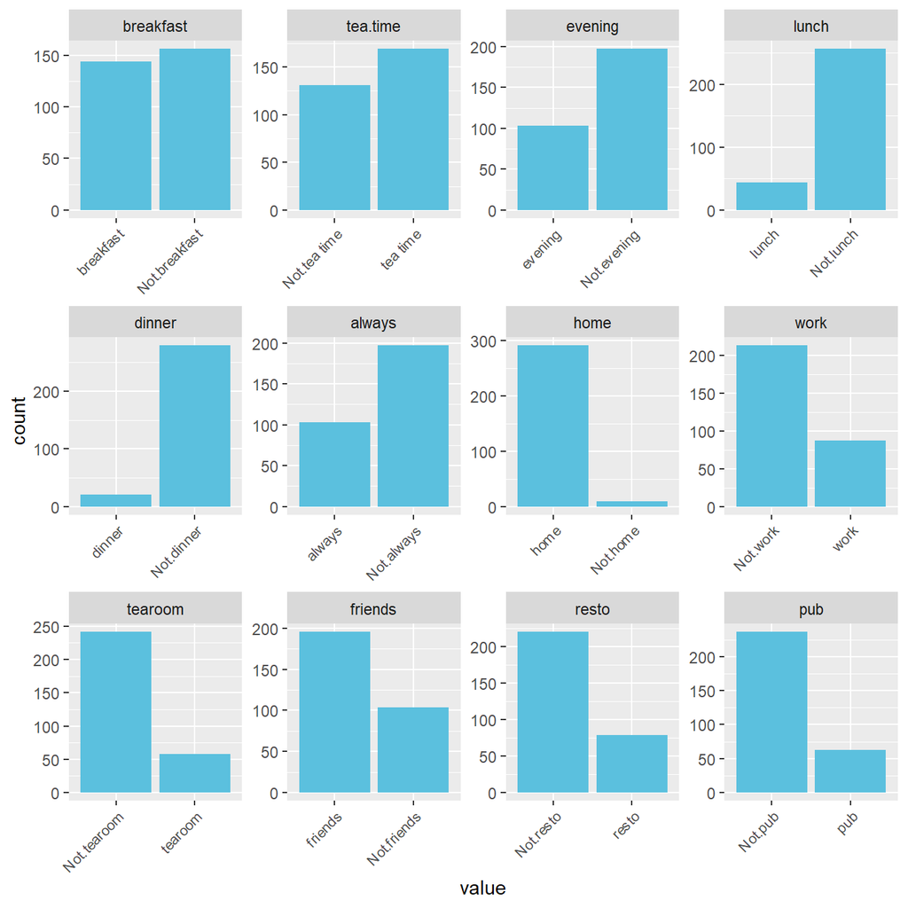

```r
tea[,1:12] %>% gather(factor_key = T) %>%
  ggplot(aes(value)) +  facet_wrap("key", scales = "free") +
  geom_bar(fill = "#5bc0de") +
  theme(axis.text.x = element_text(angle = 45, hjust = 1, size = 8))
```

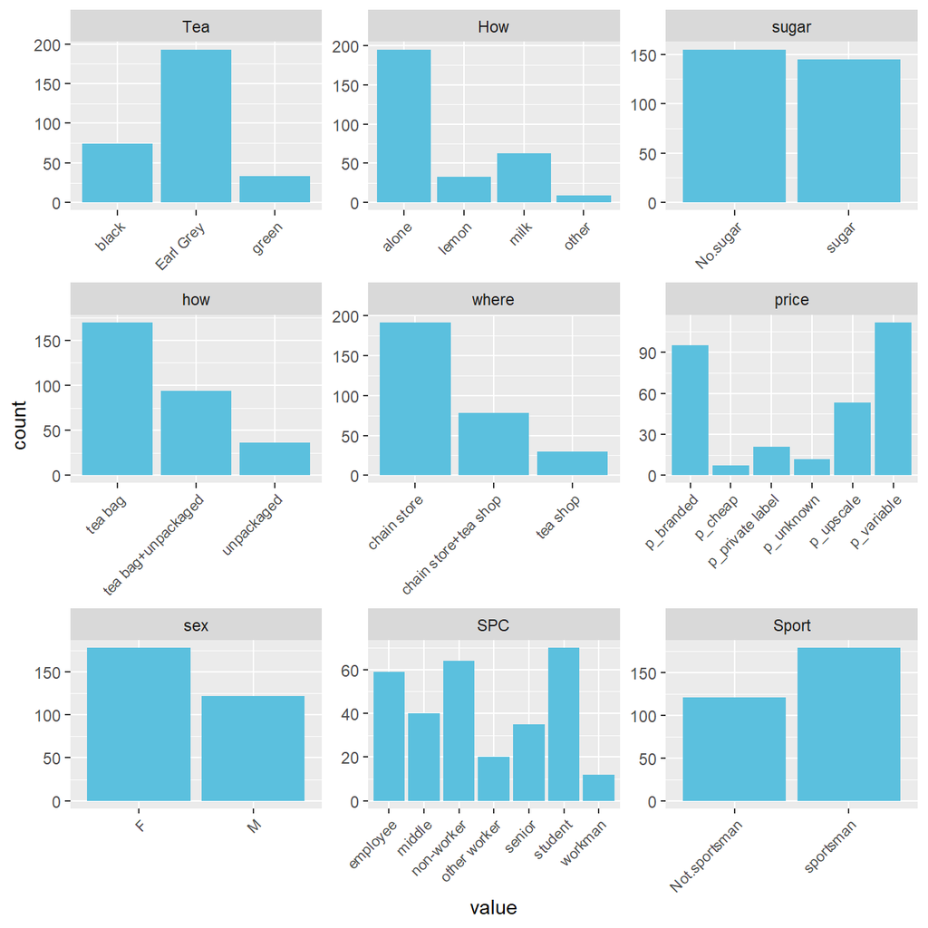

```r
tea[,c(13:18, 20:22)] %>% gather(factor_key = T) %>%
  ggplot(aes(value)) + facet_wrap("key", scales = "free") +
  geom_bar(fill = "#5bc0de") +
  theme(axis.text.x = element_text(angle = 45, hjust = 1, size = 8))
```

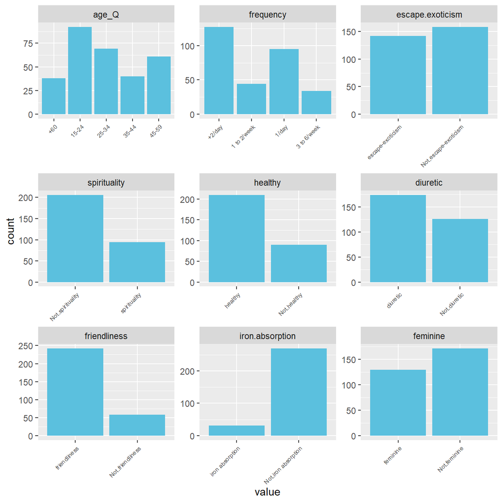

```r
tea[,23:31] %>%  gather(factor_key = T) %>%
  ggplot(aes(value)) +  facet_wrap("key", scales = "free") +
  geom_bar(fill  = "#5bc0de") +
  theme(axis.text.x = element_text(angle = 45, hjust = 1, size = 6))
```

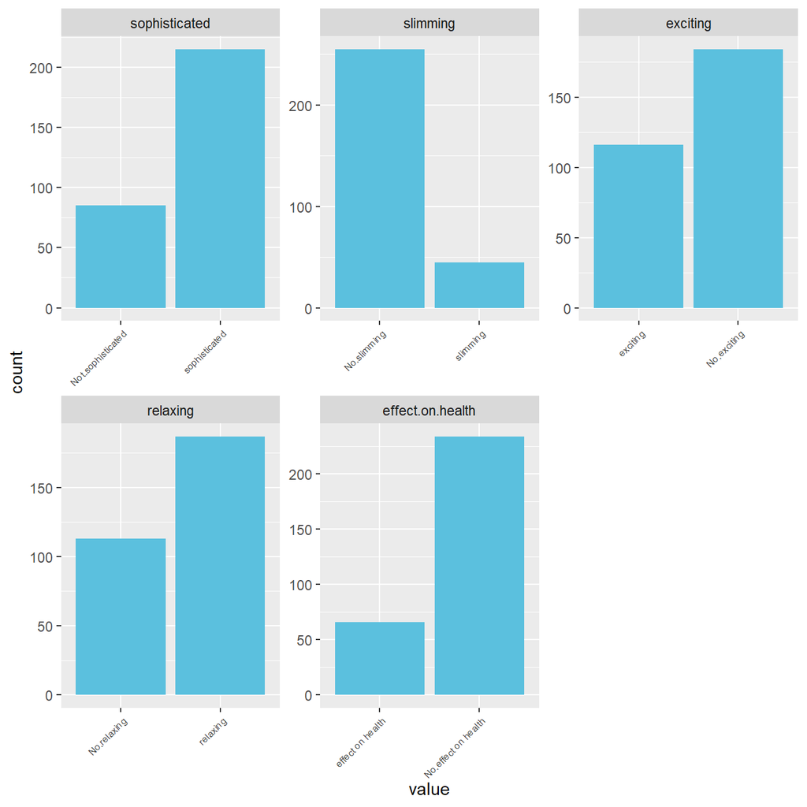

```r
tea[,32:36] %>%  gather(factor_key = T) %>%
  ggplot(aes(value)) +  facet_wrap("key", scales = "free") +
  geom_bar(fill  = "#5bc0de") +
  theme(axis.text.x = element_text(angle = 45, hjust = 1, size = 6))
```

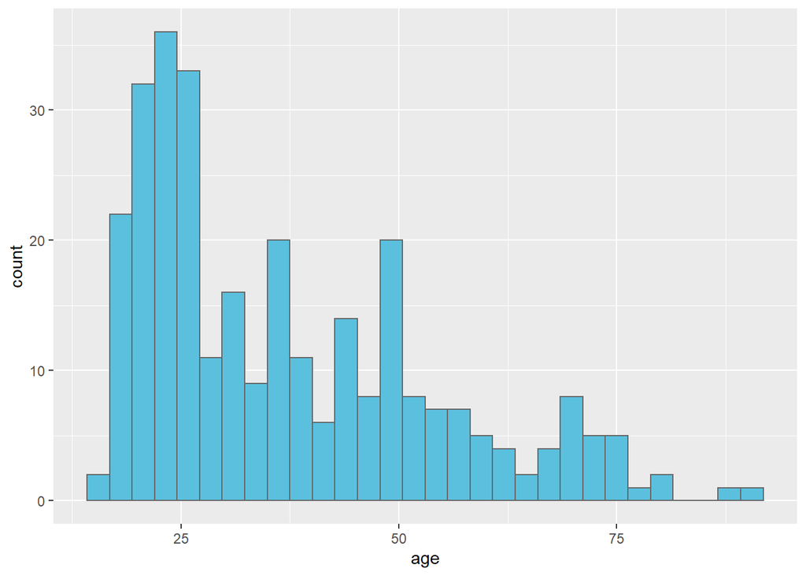

```r
tea %>% ggplot(aes(age)) + geom_histogram(fill = "#5bc0de", color = "grey40", bins = 30)
```

Selecting some variables for analysis:

```r
keep_cols <- c("Tea", "How", "how", "sugar", "where", "tea.time")
tea_ <- select(tea, one_of(keep_cols))
glimpse(tea_)
```

```
## Observations: 300
## Variables: 6
## $ Tea      <fct> black, black, Earl Grey, Earl Grey, Earl Grey, Earl G...
## $ How      <fct> alone, milk, alone, alone, alone, alone, alone, milk,...
## $ how      <fct> tea bag, tea bag, tea bag, tea bag, tea bag, tea bag,...
## $ sugar    <fct> sugar, No.sugar, No.sugar, sugar, No.sugar, No.sugar,...
## $ where    <fct> chain store, chain store, chain store, chain store, c...
## $ tea.time <fct> Not.tea time, Not.tea time, tea time, Not.tea time, N...
```

```r
mca <- MCA(tea_, graph = FALSE)
summary(mca)
```

```
##
## Call:
## MCA(X = tea_, graph = FALSE)
##
##
## Eigenvalues
##                        Dim.1   Dim.2   Dim.3   Dim.4   Dim.5   Dim.6
## Variance               0.283   0.268   0.216   0.186   0.173   0.164
## % of var.             15.455  14.611  11.777  10.169   9.417   8.956
## Cumulative % of var.  15.455  30.066  41.843  52.013  61.430  70.386
##                        Dim.7   Dim.8   Dim.9  Dim.10  Dim.11
## Variance               0.144   0.133   0.116   0.087   0.062
## % of var.              7.880   7.262   6.345   4.735   3.393
## Cumulative % of var.  78.265  85.527  91.872  96.607 100.000
##
## Individuals (the 10 first)
##                       Dim.1    ctr   cos2    Dim.2    ctr   cos2    Dim.3
## 1                  | -0.453  0.242  0.169 |  0.235  0.069  0.046 | -0.251
## 2                  | -0.310  0.113  0.056 |  0.045  0.003  0.001 | -0.672
## 3                  | -0.316  0.117  0.145 | -0.030  0.001  0.001 | -0.303
## 4                  | -0.696  0.571  0.609 |  0.208  0.054  0.055 |  0.270
## 5                  | -0.505  0.300  0.329 |  0.189  0.044  0.046 | -0.189
## 6                  | -0.505  0.300  0.329 |  0.189  0.044  0.046 | -0.189
## 7                  | -0.316  0.117  0.145 | -0.030  0.001  0.001 | -0.303
## 8                  | -0.121  0.017  0.009 | -0.174  0.038  0.018 | -0.785
## 9                  |  0.495  0.288  0.133 | -0.840  0.879  0.383 |  0.058
## 10                 |  0.597  0.420  0.197 | -0.424  0.224  0.100 | -0.387
##                       ctr   cos2
## 1                   0.097  0.052 |
## 2                   0.697  0.261 |
## 3                   0.141  0.133 |
## 4                   0.113  0.092 |
## 5                   0.055  0.046 |
## 6                   0.055  0.046 |
## 7                   0.141  0.133 |
## 8                   0.952  0.375 |
## 9                   0.005  0.002 |
## 10                  0.231  0.083 |
##
## Categories (the 10 first)
```

[output cut: 16 more lines]

```
## lemon                0.001  -0.626 |   1.589  21.447   0.312   9.661 |
## milk                 0.028  -2.870 |  -0.073   0.085   0.001  -0.647 |
## other                0.107  -5.645 |  -1.436   4.773   0.064  -4.366 |
## tea bag              0.009   1.606 |  -0.123   0.661   0.020  -2.431 |
## tea bag+unpackaged   0.271  -9.008 |   0.175   0.739   0.014   2.042 |
## unpackaged           0.362  10.410 |   0.124   0.142   0.002   0.791 |
##
## Categorical variables (eta2)
##                      Dim.1 Dim.2 Dim.3
## Tea                | 0.108 0.169 0.388 |
## How                | 0.101 0.154 0.362 |
## how                | 0.650 0.509 0.020 |
## sugar              | 0.093 0.001 0.410 |
## where              | 0.658 0.660 0.091 |
## tea.time           | 0.090 0.114 0.025 |
```

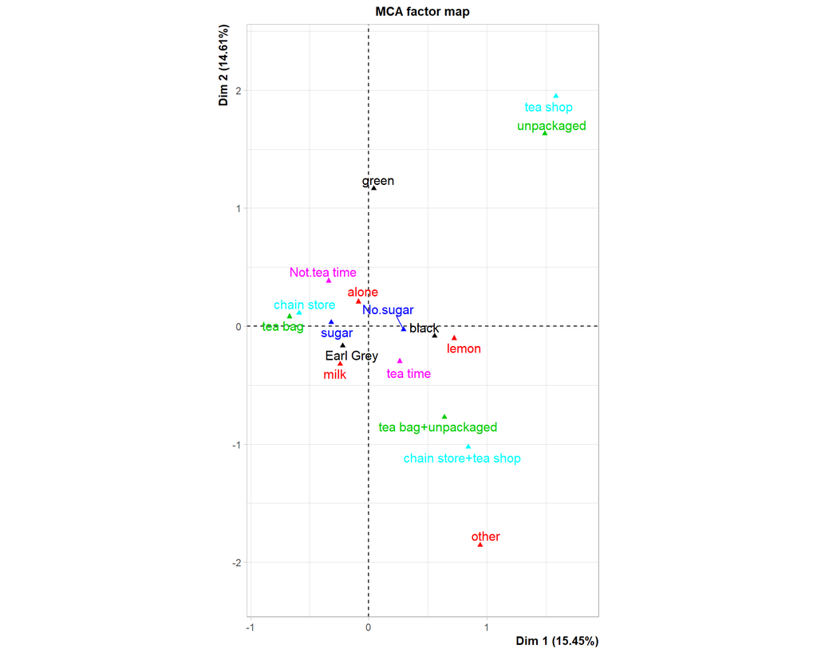

```r
plot(mca, invisible=c("ind"), habillage = "quali")
```